# WECA Report: Harrisons Wood - Zone Z015a

Author

Ewan McHenry

```r
# LIBRARIES ---------------------------------------------------------------
library(tidyverse)
library(knitr)
library(kableExtra)
library(DT)
library(htmltools)
library(ggpubr)
library(U.utilities)
library(fuzzyjoin)
library(tidyselect)
library(ggnewscale)
library(base64enc)
library(fs)
library(magick)
library(base64enc)

source("Scripts\\function-extract plot data.R")
source("Scripts\\functions_surveyreport.R")
source("Scripts\\load_weca_tables.R")

# DATA --------------------------------------------------------------------
appropriate_tree_path <- "Data\\Appropriate_tree_spp_list.csv"
appropriate_flora_path <- "Data\\Appropriate_groundflora_spp_list.csv"
high_threat_invasives_path <- "Data\\high_threat_invasives_list.csv"

microhabitats_list <- read.csv("Data\\microhabitats_list.csv")


# load value function predictions - created by "D:/Users/Ewan McHenry/OneDrive - the Woodland Trust/WEC/Woodland-condition/Estimating value functions and weightings - Delphi Round 2 analysis.qmd"
## run this script to generate the value function predictions
load("outputs\\all_value_functions.RData")
```

This doc walks through the calculation of WECA score for each indicator at each plot, and zone level, focusing on Harrisons Wood, zone Z015a.

> I have written a function that extracts the WECA survey info from the field survey form. Here I take that information and analyse it, using the value function lookup tables and weightings that were produced in Estimating value functions and weightings - Delphi Round 2 analysis, producing WECA summary scores, and WECA scores for each indicator individually.

```r
survey_data <- extract_plot_survey_data(
  excel_sheet_folderpath = site_survey_folderpath,
  excel_sheet_filename = site_survey_filename,
  sheet_appropriate_ground_flora = read.csv(appropriate_flora_path),
  sheet_appropriate_tree_spp = read.csv(appropriate_tree_path) ,
  list_high_threat_invasives = read.csv(high_threat_invasives_path)$species, # list of high threat invasive species, used to check if any are present in the plot data
  habitat_type = site_survey_habitat_type

  )

all_summaries <- create_all_summaries()
all_summaries$site_info <- list(
  wood_name = params$site_name,
  zone = params$zone_name,
  habitat_type = site_survey_habitat_type
)

dir.create("outputs/survey data summaries", showWarnings = FALSE)
save(all_summaries, file = paste0("outputs\\survey data summaries\\", survey_data[[1]]$survey_info$wood_name, "_zone_",survey_data[[1]]$survey_info$zone, ".RData"))
```

# Zone Summary

**Weighted scoring**

28

The WECA summary score (weighted) for Harrison Woodlands zone Z15a is 28/100.

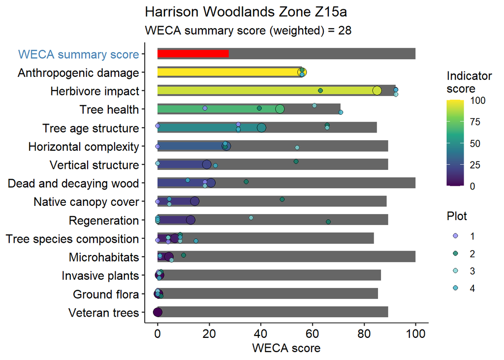

**Unweighted scoring**

30

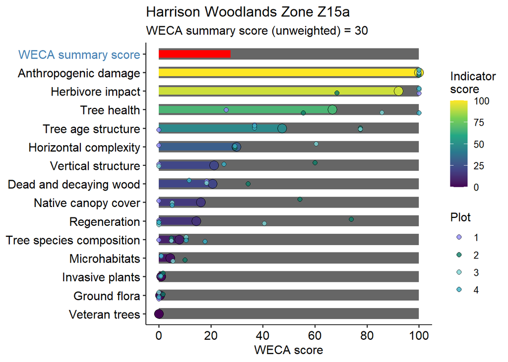

**Summary Table**

```r
datatable(
  zone_summary %>%
    mutate(value = round(value, 1),
           weighted_value = round(weighted_value, 1),
           Weighting = round(Weighting,1)) %>%
    rename(
      Indicator = indicator_name,
      Value = value,
      Weighting = Weighting,
      'Weighted value' = weighted_value
    ),
  rownames = FALSE,
  caption = "Zone Summary",
  options = list(
    pageLength = 15,
    dom = 't',
    ordering = FALSE
  )
)
```

| Indicator | Value | Weighting | Weighted value |
| --- | --- | --- | --- |
| Tree age structure | 47.4 | 84.9 | 40.2 |
| Tree species composition | 7.9 | 83.8 | 6.6 |
| Regeneration | 14.3 | 89.4 | 12.8 |
| Native canopy cover | 16.1 | 88.8 | 14.3 |
| Vertical structure | 21.2 | 89.4 | 19 |
| Invasive plants | 0.8 | 86.6 | 0.7 |
| Microhabitats | 4.3 | 100 | 4.3 |
| Horizontal complexity | 29.7 | 89.4 | 26.6 |
| Veteran trees | 0 | 89.4 | 0 |
| Dead and decaying wood | 20.6 | 100 | 20.6 |

[output cut: 4 more lines]

# Zone Map

# Plot photos

**Plot P01**

**Main plot**

[figure not shown]

**Plot P02**

**Main plot**

[figure not shown]

**Plot P03**

**Main plot**

[figure not shown]

**Plot P04**

**Main plot**

[figure not shown]

> If you’re viewing a portable shared version of this report the photos above might not load right when you click on them. Sorry! Trust me it works fine when the viewer has the photos saved on their PC!

# Survey details

**Tree info**

Detailed tree and shrub data was collected at each main and supplementary, and can be explored by expanding the plot info below.

```r
outputs <- list()

for (i in seq_along(survey_data)) {
  section_outputs <- list()

  for (df_name in c("trees_main_df", "trees_supp_df")) {
    df <- survey_data[[i]]$trees_df[[df_name]] %>%
      mutate(across(c(seedlings, saplings), as.character))

    totals <- df %>%
      summarise(across(c(young, semi_mature, early_mature, mature, spp_total_trees), ~ sum(.x, na.rm = TRUE))) %>%
      mutate(tree_species = "Total", seedlings = "", saplings = "") %>%
      select(names(df))

    df_total <- bind_rows(df, totals)

    section_outputs[[df_name]] <- datatable(
      df_total %>%
        rename(
          Species = tree_species,
          'Young (N)' = young,
          'Semi-mature (N)' = semi_mature,
          'Early mature (N)' = early_mature,
          'Mature (N)' = mature,
          'Total trees (N)' = spp_total_trees,
          Seedlings = seedlings,
          Saplings = saplings
        ) %>%
        #capitalise first letter in species names
        mutate(Species = str_to_sentence(Species)) %>%
        #order cols
        select(
          Species, `Total trees (N)`, `Young (N)`, `Semi-mature (N)`, `Early mature (N)`, `Mature (N)`, Seedlings, Saplings
        ),
      caption = paste0("Tree Data - Plot ", i, ", ", ifelse(df_name == "trees_main_df", "Main", "Supplementary")),
      rownames = FALSE,
      options = list(
        pageLength = nrow(df_total),
        dom = 't',
        ordering = FALSE
        )
    )
  }

  # Wrap in a <details> HTML element with <summary> title
plot_section <- tags$details(
  tags$summary(paste("Plot", i)),

  tags$details(
    tags$summary(style = "margin-left: 1em;", "Main Plot"),
    section_outputs$trees_main_df
  ),

  tags$details(
    tags$summary(style = "margin-left: 1em;", "Supplementary Plot"),
    section_outputs$trees_supp_df
  )
)

  outputs[[i]] <- plot_section
}

# Render all collapsible plot sections
tagList(outputs)
```

**Plot 1**

**Main Plot**

| Species | Total trees (N) | Young (N) | Semi-mature (N) | Early mature (N) | Mature (N) | Seedlings | Saplings |
| --- | --- | --- | --- | --- | --- | --- | --- |
| Oak, pedunculate | 1 | 0 | 0 | 1 | 0 | 0% Absent | 0% Absent |
| Spruce, norway | 27 | 0 | 0 | 0 | 27 | 0% Absent | 0% Absent |
| Total | 28 | 0 | 0 | 1 | 27 |  |  |

**Supplementary Plot**

| Species | Total trees (N) | Young (N) | Semi-mature (N) | Early mature (N) | Mature (N) | Seedlings | Saplings |
| --- | --- | --- | --- | --- | --- | --- | --- |
| Spruce, norway | 21 | 0 | 0 | 0 | 21 | 0% Absent | 0% Absent |
| Total | 21 | 0 | 0 | 0 | 21 |  |  |

**Plot 2**

**Main Plot**

| Species | Total trees (N) | Young (N) | Semi-mature (N) | Early mature (N) | Mature (N) | Seedlings | Saplings |
| --- | --- | --- | --- | --- | --- | --- | --- |
| Ash | 0 | 0 | 0 | 0 | 0 | &lt; 4% ( Rare - 3 Many individuals) | 0% Absent |
| Hawthorn, may | 0 | 0 | 0 | 0 | 0 | &lt; 4% ( Rare - 2 Several individuals) | 0% Absent |
| Oak, pedunculate | 4 | 0 | 0 | 4 | 0 | 0% Absent | 0% Absent |
| Poplar, black | 1 | 0 | 0 | 1 | 0 | 0% Absent | 0% Absent |
| Spruce, norway | 11 | 1 | 0 | 3 | 7 | 0% Absent | 0% Absent |
| Unknown | 0 | 0 | 0 | 0 | 0 | &lt; 4% ( Rare - 3 Many individuals) | 0% Absent |
| Total | 16 | 1 | 0 | 8 | 7 |  |  |

**Supplementary Plot**

| Species | Total trees (N) | Young (N) | Semi-mature (N) | Early mature (N) | Mature (N) | Seedlings | Saplings |
| --- | --- | --- | --- | --- | --- | --- | --- |
| Ash | 3 | 0 | 0 | 3 | 0 | 0% Absent | 0% Absent |
| Oak, pedunculate | 2 | 0 | 1 | 1 | 0 | 0% Absent | 0% Absent |
| Spruce, norway | 18 | 0 | 0 | 0 | 18 | 0% Absent | 0% Absent |
| Total | 23 | 0 | 1 | 4 | 18 |  |  |

**Plot 3**

**Main Plot**

| Species | Total trees (N) | Young (N) | Semi-mature (N) | Early mature (N) | Mature (N) | Seedlings | Saplings |
| --- | --- | --- | --- | --- | --- | --- | --- |
| Oak, pedunculate | 4 | 0 | 0 | 4 | 0 | 0% Absent | 0% Absent |
| Spruce, norway | 29 | 0 | 0 | 2 | 27 | 0% Absent | 0% Absent |
| Total | 33 | 0 | 0 | 6 | 27 |  |  |

**Supplementary Plot**

| Species | Total trees (N) | Young (N) | Semi-mature (N) | Early mature (N) | Mature (N) | Seedlings | Saplings |
| --- | --- | --- | --- | --- | --- | --- | --- |
| Hawthorn, may | 2 | 0 | 2 | 0 | 0 | 0% Absent | 0% Absent |
| Hazel | 0 | 0 | 0 | 0 | 0 | &lt; 4% ( Rare - 1 Few individuals) | 0% Absent |
| Oak, pedunculate | 1 | 0 | 0 | 1 | 0 | 0% Absent | 0% Absent |
| Spruce, norway | 23 | 0 | 0 | 0 | 23 | 0% Absent | 0% Absent |
| Total | 26 | 0 | 2 | 1 | 23 |  |  |

**Plot 4**

**Main Plot**

| Species | Total trees (N) | Young (N) | Semi-mature (N) | Early mature (N) | Mature (N) | Seedlings | Saplings |
| --- | --- | --- | --- | --- | --- | --- | --- |
| Hazel | 2 | 0 | 2 | 0 | 0 | 0% Absent | 0% Absent |
| Oak, pedunculate | 7 | 0 | 0 | 7 | 0 | 0% Absent | 0% Absent |
| Spruce, norway | 22 | 0 | 0 | 22 | 0 | 0% Absent | 0% Absent |
| Total | 31 | 0 | 2 | 29 | 0 |  |  |

**Supplementary Plot**

| Species | Total trees (N) | Young (N) | Semi-mature (N) | Early mature (N) | Mature (N) | Seedlings | Saplings |
| --- | --- | --- | --- | --- | --- | --- | --- |
| Ash | 1 | 0 | 0 | 1 | 0 | 0% Absent | 0% Absent |
| Hazel | 1 | 0 | 1 | 0 | 0 | 0% Absent | 0% Absent |
| Oak, pedunculate | 2 | 0 | 0 | 2 | 0 | 0% Absent | 0% Absent |
| Spruce, norway | 10 | 0 | 0 | 10 | 0 | 0% Absent | 0% Absent |
| Total | 14 | 0 | 1 | 13 | 0 |  |  |

**Tree age structure**

```r
this.sheet <- "Tree Age distribution"
x.axis_title <- "Number of tree age classes"
age_summary <- create_age_summary()
```

47

The mean age structure value across the zone is 47.36.

Age structure value is a function of the number of different age classes present in each plot and is presented in the table below.

A Shannon diversity index could be an alternative measure with which to infer value, it considers the the number of trees in each age class and the degree to which age classes might dominate.

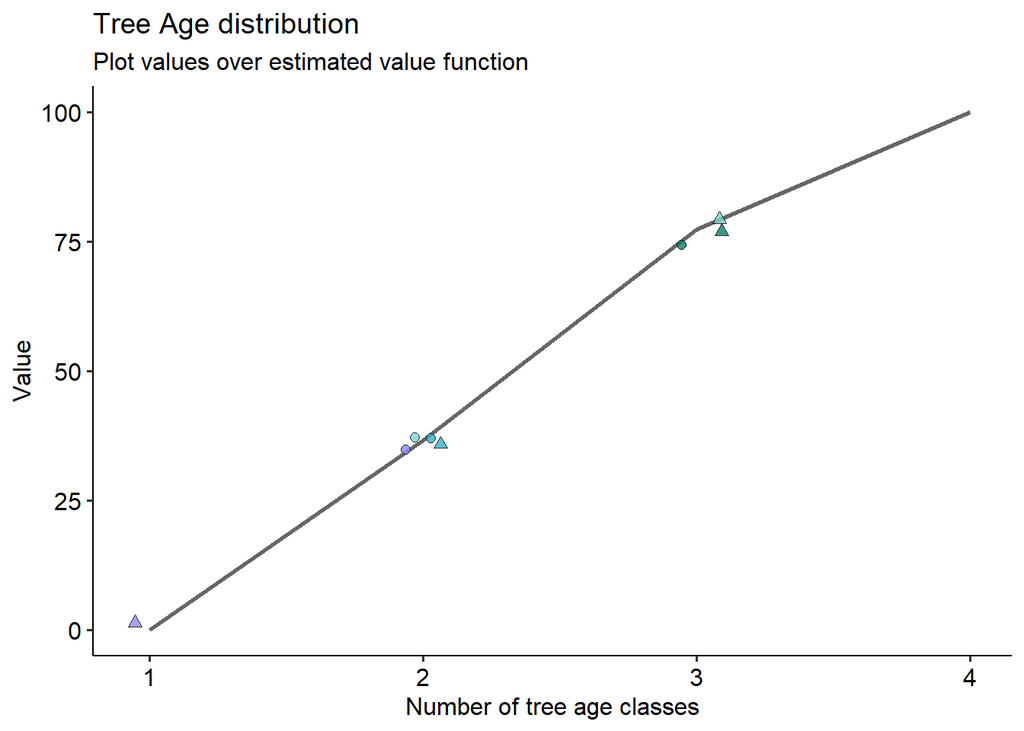

```r
ggplot() +
  geom_line(
    data = age_structure_predictions,
    aes(x = measure, y = value),
    color = "black", linewidth = vf_size, alpha = vf_alpha
  ) +
  geom_point(
    data = age_summary,
    aes(
      x = age_classes_n,
      y = value,
      fill = plot,
      shape = plot_type
    ),
    alpha = point_alpha,
    size = point_size,
    position = position_jitter(width = 0.1, height = 3),
    colour = "black"
  ) +
  scale_shape_manual(values = c(21, 24)) +
  scale_fill_manual(values= wt_palette[-c(1,2,4)]) +
  # Axes and titles
  labs(
    x = x.axis_title,
    y = "Value",
    title = paste(this.sheet),
    subtitle = "Plot values over estimated value function",
    fill = "Plot type"
  ) +
  # Theme and tweaks
  theme_pubr() +
  theme(legend.position = "none")
```

```r
datatable(
  age_summary %>%
    mutate(
      value = round(value, 2),
      shannon = round(shannon, 2),
      plot = as.factor(plot),
      plot_type = as.factor(plot_type)
    ) %>%
    rename(     Plot = plot,
      'Plot type' = plot_type,
      Value = value,
      'Age classes (N)' = age_classes_n,
      'Shannon diversity index' = shannon,
      'Young (N)' = young,
      'Semi-mature (N)' = semi_mature,
      'Early mature (N)' = early_mature,
      'Mature (N)' = mature
      ),
  rownames = FALSE,
  caption = "Tree Age Class Summary",
  options = list(
    pageLength = 10,
    dom = 't',
    ordering = FALSE,
    scrollX = TRUE  # ← Enables horizontal scrolling
  )
)
```

| Plot | Plot type | Value | Age classes (N) | Shannon diversity index | Young (N) | Semi-mature (N) | Early mature (N) | Mature (N) |
| --- | --- | --- | --- | --- | --- | --- | --- | --- |
| 1 | main | 36.71 | 2 | 0.15 | 0 | 0 | 1 | 27 |
| 1 | supp | 0 | 1 | 0 | 0 | 0 | 0 | 21 |
| 2 | main | 77.36 | 3 | 0.88 | 1 | 0 | 8 | 7 |
| 2 | supp | 77.36 | 3 | 0.63 | 0 | 1 | 4 | 18 |
| 3 | main | 36.71 | 2 | 0.47 | 0 | 0 | 6 | 27 |
| 3 | supp | 77.36 | 3 | 0.43 | 0 | 2 | 1 | 23 |
| 4 | main | 36.71 | 2 | 0.24 | 0 | 2 | 29 | 0 |
| 4 | supp | 36.71 | 2 | 0.26 | 0 | 1 | 13 | 0 |

**Tree species richness**

```r
this.sheet <- "Native tree and shrub species: proportion of appropraite present"
x.axis_title <- "Proportion of appropriate tree/shrub species present"

tree_species_summary <- create_tree_species_summary()
```

8

The mean tree species richness value across the zone is 7.88.

Tree species richness value is a function of the proportion of appropriate tree and shrub species found in each plot (appropriate species lists are habitat-specific).

A Shannon diversity index could be an alternative measure with which to infer value, it considers the number of trees in each species and the degree to which species might dominate.

The appropriate tree and shrub species list for this habitat type (base rich lowland) has 24 species in it, they are: apple, crab / wild; ash; aspen; beech, common; birch sp.; birch, downy; birch, silver; blackthorn; cherry, wild; dogwood; elder; elm, wych; guelder rose; hawthorn, may; hazel; holly; maple, field; oak, pedunculate; pear, wild; privet, wild; rowan; spindle; willow sp.; yew.

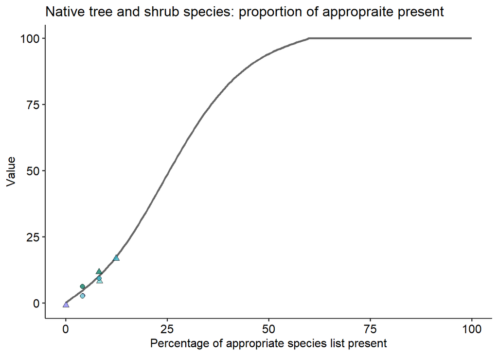

```r
ggplot() +
  geom_line(
    data = n_tree_shrub_spp_predictions,
    aes(x = measure, y = value),
    color = "black", size = vf_size, alpha = vf_alpha
  ) +
  geom_point(
    data = tree_species_summary,
    aes(
      x = per_of_appropriate_species,
      y = value,
      fill = plot,
      shape = plot_type
    ),
    alpha = point_alpha,
    size = point_size,
    colour = "black",
    position = position_jitter(width = 0.1, height = 3)
  ) +
  scale_shape_manual(values = c(21, 24)) +
  scale_fill_manual(values= wt_palette[-c(1,2,4)]) +
  # Axes and titles
  labs(
    x = "Percentage of appropriate species list present",
    y = "Value",
    title = paste(this.sheet),
    fill = "Plot type"
  ) +
  # Theme and tweaks
  theme_pubr() +
  theme(legend.position = "none")
```

```r
datatable(
  tree_species_summary %>%
    mutate(
      value = round(value, 1),
      shannon_index_appropriate = round(shannon_index_appropriate, 2),
      per_of_appropriate_species = paste(round(per_of_appropriate_species, 0), "%", sep = "")
    ) %>%
     rename(
           Plot = plot,
           'Plot type' = plot_type,
           Value = value,
           'Percent of appropriate species list present' = per_of_appropriate_species,
           'Species richness (N)' = spp_n,
           'Appropriate species richness (N)' = N_appropriate_species,
           'Shannon diversity of appropriate species' = shannon_index_appropriate
           )  %>%
    # make all col names capitalised first letter
    rename_with(
      ~ str_to_sentence(.)
      ),
  rownames = FALSE,
  caption = "Tree Species Richness Summary by Plot and Subplot",
  options = list(
    pageLength = 10,
    dom = 't',
    ordering = FALSE,
    scrollX = TRUE  # ← Enables horizontal scrolling
  )
)
```

| Plot | Plot type | Value | Percent of appropriate species list present | Appropriate species richness (n) | Species richness (n) | Shannon diversity of appropriate species | Ash | Hawthorn, may | Hazel | Oak, pedunculate | Poplar, black | Spruce, norway |
| --- | --- | --- | --- | --- | --- | --- | --- | --- | --- | --- | --- | --- |
| 1 | main | 4.7 | 4% | 1 | 2 | 0 | 0 | 0 | 0 | 1 | 0 | 27 |
| 1 | supp | 0 | 0% | 0 | 1 | 0 | 0 | 0 | 0 | 0 | 0 | 21 |
| 2 | main | 4.7 | 4% | 1 | 3 | 0 | 0 | 0 | 0 | 4 | 1 | 11 |
| 2 | supp | 10.4 | 8% | 2 | 3 | 0.67 | 3 | 0 | 0 | 2 | 0 | 18 |
| 3 | main | 4.7 | 4% | 1 | 2 | 0 | 0 | 0 | 0 | 4 | 0 | 29 |
| 3 | supp | 10.4 | 8% | 2 | 3 | 0.64 | 0 | 2 | 0 | 1 | 0 | 23 |
| 4 | main | 10.4 | 8% | 2 | 3 | 0.53 | 0 | 0 | 2 | 7 | 0 | 22 |
| 4 | supp | 17.6 | 12% | 3 | 4 | 1.04 | 1 | 0 | 1 | 2 | 0 | 10 |

**Regen**

```r
this.sheet <- "Tree & shrub regen"
x.axis_title <- "Number of regen classes present"
regen_summary <- create_regen_summary()
```

14

The mean regen value across the zone is 14.3.

Regen value is a function of the number of regen classes of trees or shrubs present in each plot (seedlings, saplings and young trees).

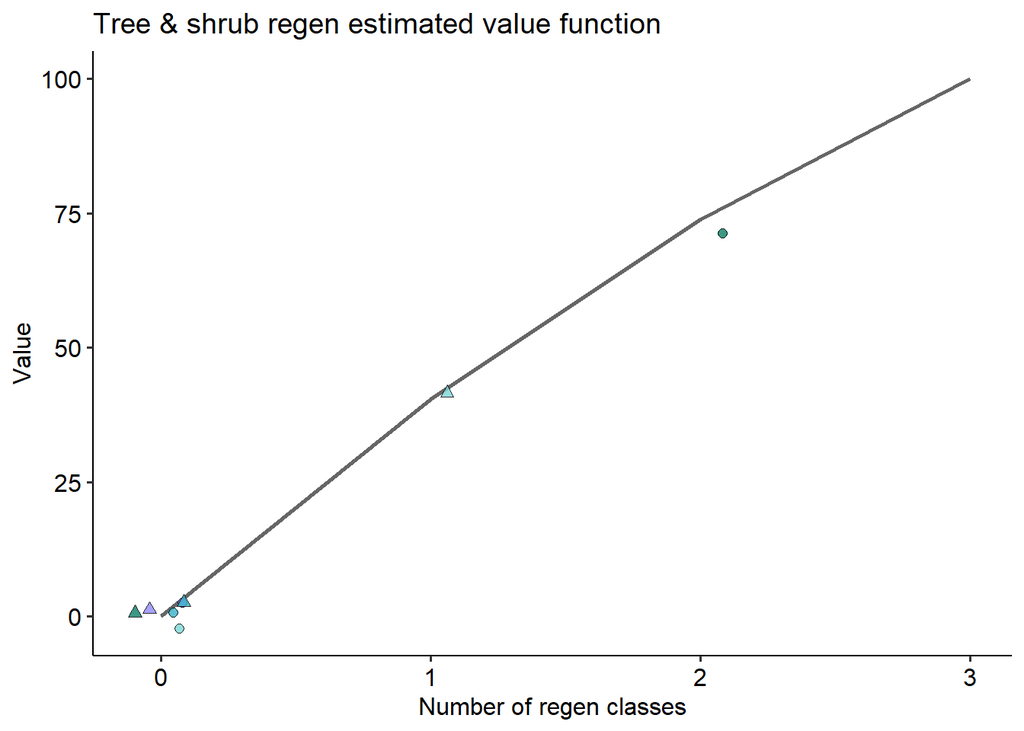

```r
ggplot() +
  geom_line(
    data = regen_predictions,
    aes(x = measure, y = value),
    color = "black", size = vf_size, alpha = vf_alpha
  ) +
  geom_point(
    data = regen_summary,
    aes(
      x = regen_classes_n,
      y = value,
      fill = plot,
      shape = plot_type
    ),
    alpha = point_alpha,
    size = point_size,
    colour = "black",
    position = position_jitter(width = 0.1, height = 3)
  ) +
  scale_shape_manual(values = c(21, 24)) +
  scale_fill_manual(values= wt_palette[-c(1,2,4)]) +
  # Axes and titles
  labs(
    x = "Number of regen classes",
    y = "Value",
    title = paste(this.sheet, "estimated value function"),
    fill = "Plot type"
  ) +
  # Theme and tweaks
  theme_pubr() +
  theme(legend.position = "none")
```

```r
datatable(
  regen_summary %>%
    mutate(
      value = round(value, 2),
      regen_classes_n = as.character(regen_classes_n)
    ) %>%
    rename(
      Plot = plot,
      'Plot type' = plot_type,
      Value = value,
      'Number of regen classes' = regen_classes_n
    ),
  rownames = FALSE,
  caption = "Regen Summary by Plot and Subplot",
  options = list(
    pageLength = 10,
    dom = 't',
    ordering = FALSE,
    scrollX = TRUE  # ← Enables horizontal scrolling
  )
)
```

| Plot | Plot type | Value | Number of regen classes | young | seedlings | saplings |
| --- | --- | --- | --- | --- | --- | --- |
| 1 | main | 0 | 0 | False | False | False |
| 1 | supp | 0 | 0 | False | False | False |
| 2 | main | 73.92 | 2 | True | True | False |
| 2 | supp | 0 | 0 | False | False | False |
| 3 | main | 0 | 0 | False | False | False |
| 3 | supp | 40.45 | 1 | False | True | False |
| 4 | main | 0 | 0 | False | False | False |
| 4 | supp | 0 | 0 | False | False | False |

**Native canopy cover**

```r
this.sheet <- "Native canopy percentage"
x.axis_title <- "Canopy nativness (% of total canopy volume)"
native_canopy_summary <- create_native_canopy_summary()
```

16

The mean native canopy cover value across the zone is 16.09.

Native canopy cover value is a function of the proportion of each plots’s total canopy volume made up of UK native tree and shrub species.

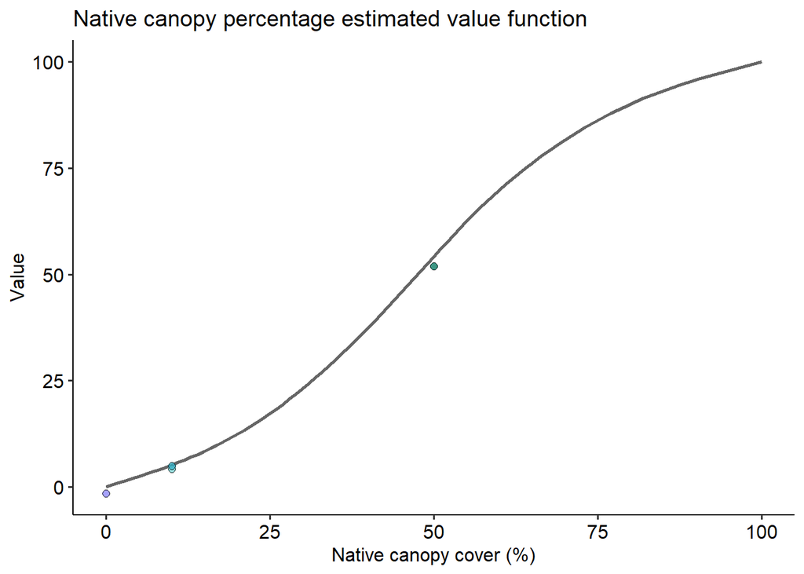

```r
ggplot() +
  geom_line(
    data = native_canopy_predictions,
    aes(x = measure, y = value),
    color = "black", size = vf_size, alpha = vf_alpha
  ) +
  geom_point(
    data = native_canopy_summary,
    aes(
      x = native_canopy_cover,
      y = value,
      fill = plot
    ),
    alpha = point_alpha,
    size = point_size,
    shape = 21, colour = "black",
    position = position_jitter(width = 0.1, height = 3)
  ) +
  scale_fill_manual(values= wt_palette[-c(1,2,4)]) +
  # Axes and titles
  labs(
    x = "Native canopy cover (%)",
    y = "Value",
    title = paste(this.sheet, "estimated value function"),
    fill = "Plot type"
  ) +
  # Theme and tweaks
  theme_pubr() +
  theme(legend.position = "none")
```

```r
datatable(
  native_canopy_summary %>%
    mutate(
      value = round(value, 2),
      native_canopy_cover = paste(round(native_canopy_cover, 2), "%", sep = "")
    ) %>%
    rename(
      Plot = plot,
      Value = value,
      'Native canopy cover' = native_canopy_cover
    ),
  rownames = FALSE,
  caption = "Native Canopy Cover Summary by Plot",
  options = list(
    pageLength = 10,
    dom = 't',
    ordering = FALSE
  )
)
```

| Plot | Value | Native canopy cover |
| --- | --- | --- |
| 1 | 0 | 0% |
| 2 | 54.22 | 50% |
| 3 | 5.07 | 10% |
| 4 | 5.07 | 10% |

**Vertical structure**

```r
this.sheet <- "Vertical structure"
x.axis_title <- "Number of vertical strata present"
vertical_structure_summary <- create_vertical_structure_summary()
```

21

The mean vertical structure value across the zone is 21.22.

Vertical structure value is a function of the number of different vertical strata present in each plot, where the cover of that strata is ecologically significant (> 10%).

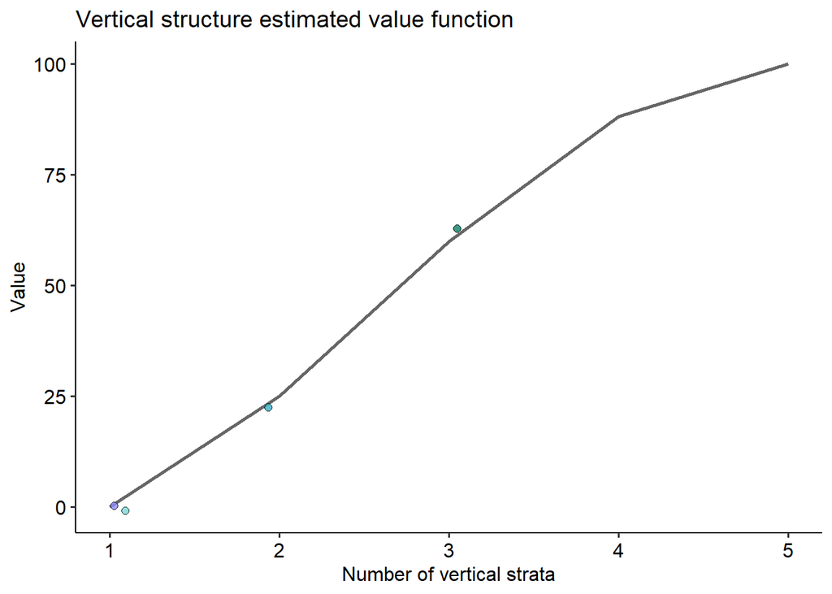

```r
ggplot() +
  geom_line(
    data = vertical_structure_predictions,
    aes(x = measure, y = value),
    color = "black", size = vf_size, alpha = vf_alpha
  ) +
  geom_point(
    data = vertical_structure_summary,
    aes(
      x = vertical_structure_n,
      y = value,
      fill = plot
    ),
    alpha = point_alpha,
    size = point_size,
    shape = 21, colour = "black",
    position = position_jitter(width = 0.1, height = 3)
  ) +
  scale_fill_manual(values= wt_palette[-c(1,2,4)]) +
  # Axes and titles
  labs(
    x = "Number of vertical strata",
    y = "Value",
    title = paste(this.sheet, "estimated value function"),
    fill = "Plot type"
  ) +
  # Theme and tweaks
  theme_pubr() +
  theme(legend.position = "none")
```

```r
datatable(
  vertical_structure_summary %>%
    mutate(
      value = round(value, 2),
      vertical_structure_n = as.character(vertical_structure_n)
    ) %>%
    rename(
      Plot = plot,
      Value = value,
      'Number of strata' = vertical_structure_n
    ),
  rownames = FALSE,
  caption = "Vertical Structure Summary by Plot",
  options = list(
    pageLength = 10,
    dom = 't',
    ordering = FALSE,
    scrollX = TRUE  # ← Enables horizontal scrolling
  )
)
```

| Plot | Value | Number of strata | Ground layer (0 - 0.1m) | Field layer (0.1 - 1m) | Shrub (1 - 5m) | Lower (5 -12m) | Middle (12 -20m) | Upper (20m+) |
| --- | --- | --- | --- | --- | --- | --- | --- | --- |
| 1 | 0 | 1 | 0% Absent | 0% Absent | 0% Absent | 0% Absent | &lt; 4% ( Rare - 1 Few individuals) | 90 – 100% (Dominant - 10) |
| 2 | 59.94 | 3 | 4 - 10% (Rare - 4) | 4 - 10% (Rare - 4) | &lt; 4% ( Rare - 3 Many individuals) | 33 – 50% (Frequent - 7) | 26 – 33% (Frequent - 6) | 26 – 33% (Frequent - 6) |
| 3 | 0 | 1 | 0% Absent | 0% Absent | &lt; 4% ( Rare - 1 Few individuals) | &lt; 4% ( Rare - 2 Several individuals) | &lt; 4% ( Rare - 2 Several individuals) | 75 – 90% (Dominant - 9) |
| 4 | 24.95 | 2 | 0% Absent | 0% Absent | &lt; 4% ( Rare - 3 Many individuals) | 4 - 10% (Rare - 4) | 10 – 25% ( Occasional - 5) | 90 – 100% (Dominant - 10) |

**Invasive plants**

```r
this.sheet <- "Invasive plants"
x.axis_title <- "Total invasive cover (%)"
invasives_summary <- create_invasives_summary()
```

1

The mean invasives value across the zone is 0.79.

Invasives value is a function of the total cover of invasive species in each plot, overwritten with a zero value if any high threat invasive species are present.

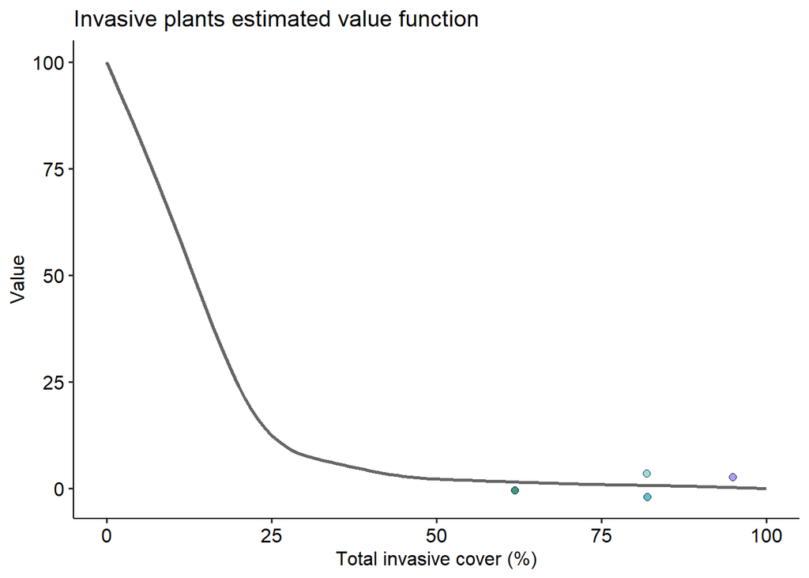

```r
ggplot() +
  geom_line(
    data = invasive_plants_predictions,
    aes(x = measure, y = value),
    color = "black", size = vf_size, alpha = vf_alpha
  ) +
  geom_point(
    data = invasives_summary,
    aes(
      x = dummy_measure,
      y = value,
      fill = plot
    ),
    alpha = point_alpha,
    size = point_size,
    shape = 21, colour = "black",
    position = position_jitter(width = 0.1, height = 3)
  ) +
  scale_fill_manual(values= wt_palette[-c(1,2,4)]) +
  # Axes and titles
  labs(
    x = "Total invasive cover (%)",
    y = "Value",
    title = paste(this.sheet, "estimated value function"),
    fill = "Plot type"
  ) +
  # Theme and tweaks
  theme_pubr() +
  theme(legend.position = "none")
```

```r
datatable(
  invasives_summary %>%
    mutate(
      value = round(value, 2),
      total_invasive_domin_cover = total_invasive_domin_cover,
      high_threat_spp_present = ifelse(high_threat_spp_present, "Yes", "No")
    ) %>%
    select(-dummy_measure) %>% # remove dummy measure column
    rename(
      Plot = plot,
      Value = value,
      'Total invasive cover' = total_invasive_domin_cover,
      'High threat species present' = high_threat_spp_present
    ),
  rownames = FALSE,
  caption = "Invasive Species Summary by Plot",
  options = list(
    pageLength = 10,
    dom = 't',
    ordering = FALSE
  )
)
```

| Plot | Value | Total invasive cover | High threat species present | spruce,_norway |
| --- | --- | --- | --- | --- |
| 1 | 0.23 | 90 – 100% (Dominant - 10) | No |  |
| 2 | 1.5 | 50 – 75% (Abundant - 8) | No |  |
| 3 | 0.71 | 75 – 90% (Dominant - 9) | No |  |
| 4 | 0.71 | 75 – 90% (Dominant - 9) | No |  |

**Microhabitats**

```r
this.sheet <- "Microhabitats"
x.axis_title <- "Proportion of microhabitats present (%)"
microhabitats_summary <- create_microhabitats_summary()
```

4

The mean microhabitats value across the zone is 4.29.

Microhabitats value is a function of the proportion of all possible microhabitats present in each plot.

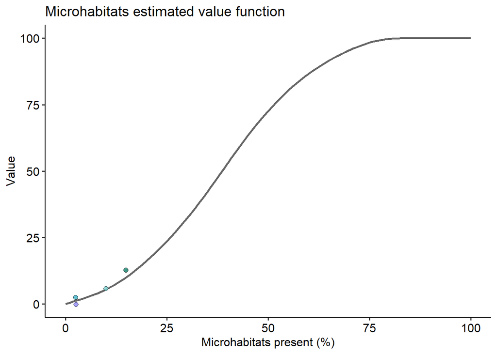

```r
ggplot() +
  geom_line(
    data = microhab_vf_predictions,
    aes(x = measure, y = value),
    color = "black", size = vf_size, alpha = vf_alpha
  ) +
  geom_point(
    data = microhabitats_summary,
    aes(
      x = microhabitats_prop,
      y = value,
      fill = plot
    ),
    alpha = point_alpha,
    size = point_size,
    shape = 21, colour = "black",
    position = position_jitter(width = 0.1, height = 3)
  ) +
  scale_fill_manual(values= wt_palette[-c(1,2,4)]) +
  # Axes and titles
  labs(
    x = "Microhabitats present (%)",
    y = "Value",
    title = paste(this.sheet, "estimated value function"),
    fill = "Plot type"
  ) +
  # Theme and tweaks
  theme_pubr() +
  theme(legend.position = "none")
```

```r
datatable(
  microhabitats_summary %>%
    mutate(
      value = round(value, 2),
      microhabitats_prop = paste(round(microhabitats_prop, 2), "%", sep = ""),
      microhabitats_n = as.character(microhabitats_n)
    ) %>%
    rename(
      Plot = plot,
      Value = value,
      'Microhabitats present (%)' = microhabitats_prop,
      'Number of microhabitats' = microhabitats_n
    ),
  rownames = FALSE,
  caption = "Microhabitats Summary by Plot",
  options = list(
    pageLength = 10,
    dom = 't',
    ordering = FALSE,
    scrollX = TRUE  # ← Enables horizontal scrolling
  )
)
```

| Plot | Value | Microhabitats present (%) | Number of microhabitats | 006 Trunk rot-hole (closed top, no ground contact) ø > 10 cm | 010 Hollow branch ø > 10 cm | 018 Bark shelter a >1 cm, b >10 cm, c >10 cm | 019 Bark pocket a >1 cm, b >10 cm, c >10 cm | 026 Dead branches ø > 10 cm, or ø > 3 cm plus > 10% crown is dead | 030 Epicormic shoots > 5 shoots | 040 Bryophytes (mosses and liverworts) > 10% of the trunk is covered | 051 Sap run Length > 10 cm | 052 Heavy resinosis Length > 10 cm |
| --- | --- | --- | --- | --- | --- | --- | --- | --- | --- | --- | --- | --- |
| 1 | 0.87 | 2.5% | 1 | False | False | False | False | False | False | False | True | False |
| 2 | 10.01 | 15% | 6 | True | True | True | True | True | False | True | False | False |
| 3 | 5.4 | 10% | 4 | False | False | False | False | True | True | False | True | True |
| 4 | 0.87 | 2.5% | 1 | False | False | False | False | False | False | False | True | False |

**Horizontal complexity**

```r
this.sheet <- "Horizontal complexity"
horizontal_complexity_summary <- create_horizontal_complexity_summary()
```

30

The mean horizontal complexity value across the zone is 29.71. Horizontal complexity value is a function of the number of different top height categories present in each plot, and the Shannon diversity index of those categories.

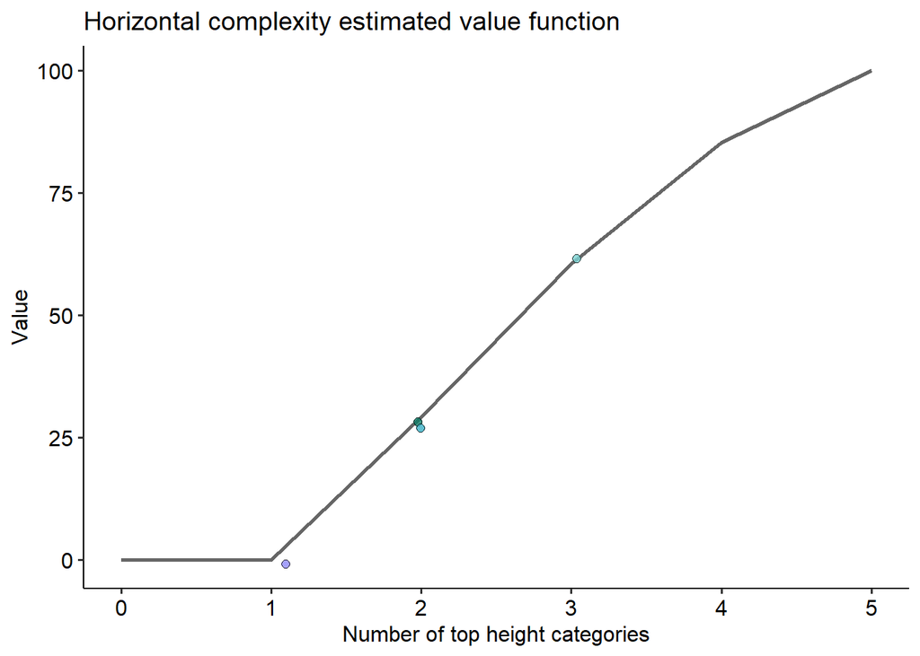

```r
ggplot() +
  geom_line(
    data = horizontal_complexity_predictions,
    aes(x = measure, y = value),
    color = "black", size = vf_size, alpha = vf_alpha
  ) +
  geom_point(
    data = horizontal_complexity_summary,
    aes(
      x = N_topheight_cats,
      y = value,
      fill = plot
    ),
    alpha = point_alpha,
    size = point_size,
    shape = 21, colour = "black",
    position = position_jitter(width = 0.1, height = 3)
  ) +
  scale_fill_manual(values= wt_palette[-c(1,2,4)]) +
  # Axes and titles
  labs(
    x = "Number of top height categories",
    y = "Value",
    title = paste(this.sheet, "estimated value function"),
    fill = "Plot type"
  ) +
  # Theme and tweaks
  theme_pubr() +
  theme(legend.position = "none")
```

```r
datatable(
  horizontal_complexity_summary %>%
    mutate(
      value = round(value, 2),
      N_topheight_cats = as.character(N_topheight_cats),
      shannon_topheight_cats = round(shannon_topheight_cats, 2)
    ) %>%
    rename(
      Plot = plot,
      Value = value,
      'Number of top height categories' = N_topheight_cats,
      'Shannon index' = shannon_topheight_cats
    ),
  rownames = FALSE,
  caption = "Horizontal Complexity Summary by Plot",
  options = list(
    pageLength = 10,
    dom = 't',
    ordering = FALSE,
    scrollX = TRUE  # ← Enables horizontal scrolling
  )
)
```

| Plot | Value | Number of top height categories | Shannon index | Ground layer (0 - 0.1m) | Field layer (0.1 - 1m) | Shrub (1 - 5m) | Lower (5 -12m) | Middle (12 -20m) | Upper (20m+) |
| --- | --- | --- | --- | --- | --- | --- | --- | --- | --- |
| 1 | 0 | 1 | 0 | 0 | 0 | 0 | 0 | 0 | 10 |
| 2 | 29.17 | 2 | 0.33 | 0 | 0 | 0 | 0 | 1 | 9 |
| 3 | 60.48 | 3 | 0.64 | 1 | 0 | 0 | 0 | 1 | 8 |
| 4 | 29.17 | 2 | 0.33 | 0 | 0 | 0 | 0 | 1 | 9 |

**Veteran trees**

```r
this.sheet <- "Veteran trees"
x.axis_title <- "Veteran trees per ha"
veteran_trees_summary <- create_veteran_trees_summary()

# estimate mean avt density AND 95% CI across plots
avt_dens_mean <- mean(veteran_trees_summary$dens_avt, na.rm = TRUE)
# Standard error of the mean
avt_dens_se <- sd(veteran_trees_summary$dens_avt) / sqrt(length(veteran_trees_summary$dens_avt))

# 95% confidence interval
avt_dens_ci_lower <- avt_dens_mean - qt(0.975, df = length(veteran_trees_summary$dens_avt) - 1) * avt_dens_se
avt_dens_ci_upper <- avt_dens_mean + qt(0.975, df = length(veteran_trees_summary$dens_avt) - 1) * avt_dens_se

# corresponding value (nearest)
avt_value <- veteran_trees_lookup$value[
  which.min(abs(veteran_trees_lookup$N.Veteran.Trees.per.ha - avt_dens_mean))
]
avt_value_95ci <- veteran_trees_lookup$value[
  c(which.min(abs(veteran_trees_lookup$N.Veteran.Trees.per.ha - avt_dens_ci_lower)) ,
  which.min(abs(veteran_trees_lookup$N.Veteran.Trees.per.ha - avt_dens_ci_upper)))
]
```

0

The veteran trees value across the zone is 0 (0 - 0 95% CI), based on an estimated mean AVT density of 0 (0 - 0 95% CI) per ha.

Note: value for the AVT indicator is calculated based on the mean AVT density across all plots, rather than the mean value across plots, as AVT condition opperates at too large a scale to be captured by individual plots.

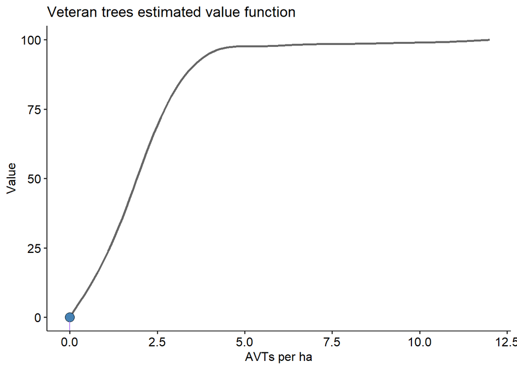

Estimated value for AVTs with 95% confidence interval, based on estiamte of mean avt density across the survey area. The line represents the value function for AVT density. x axis rug marks show the avt density recorded at each plot (truncated to the x axis maximum).

```r
#trncate plot density to max on figure and add a jitter
plotting.denses = data.frame(plot = veteran_trees_summary$plot,
                             dens.ests = veteran_trees_summary$dens_avt %>%
                               jitter(0.1))
plotting.denses$dens.ests[plotting.denses$dens.ests > max(veteran_trees_predictions$measure)] <- max(veteran_trees_predictions$measure)


ggplot() +
  geom_line(
    data = veteran_trees_predictions,
    aes(x = measure, y = value),
    color = "black", size = vf_size, alpha = vf_alpha
  ) +
  geom_point(
    aes(
      x = avt_dens_mean,
      y = avt_value
    ),
    # alpha = point_alpha,
    size = point_size*2,
    fill = "steelblue", shape = 21, colour = "black"
  ) +
  # Add 95% CI as error bars
  geom_errorbar(
    aes(
      x = avt_dens_mean,
      ymin = avt_value_95ci[1],
      ymax = avt_value_95ci[2]
    ),
    width = 0.1, colour = "steelblue", size = 0.5
  ) +
  # x axis rug marks for density in each plot, truncated to max from veteran_trees_predictions
  geom_rug(
    data = plotting.denses,
    aes(x = dens.ests, colour = as.factor(plot)),
    sides = "b",
    alpha = 0.9, size = 0.5
  ) +
    scale_fill_manual(values= wt_palette[-c(1,2,4)]) +
# Axes and titles
  labs(
    x = "AVTs per ha",
    y = "Value",
    title = paste(this.sheet, "estimated value function")
  ) +
  # Theme and tweaks
  theme_pubr() +
  theme(legend.position = "none")
```

```r
datatable(
  veteran_trees_summary %>%
    mutate(
      N_avt_n = as.character(N_avt_n),
      dens_avt = round(dens_avt, 2)
    ) %>%
    rename(
      Plot = plot,
      'Number of AVTs' = N_avt_n,
      'AVT density (per ha)' = dens_avt
    ),
  rownames = FALSE,
  caption = "Veteran Trees Summary by Plot",
  options = list(
    pageLength = 10,
    dom = 't',
    ordering = FALSE
  )
)
```

| Plot | Number of AVTs | AVT density (per ha) |
| --- | --- | --- |
| 1 | 0 | 0 |
| 2 | 0 | 0 |
| 3 | 0 | 0 |
| 4 | 0 | 0 |

**Dead and decaying wood**

```r
this.sheet <- "Dead and decaying wood"
x.axis_title <- "Mean deadwood-types (of four types) per plot quarter"
dead_decaying_wood_summary <- create_dead_decaying_wood_summary()
```

21

The mean dead and decaying wood value across the zone is 20.62.

Dead and decaying wood value is a function of the mean number of deadwood types (standing, fallen, stumps and in-canopy) per plot quarter (max 4).

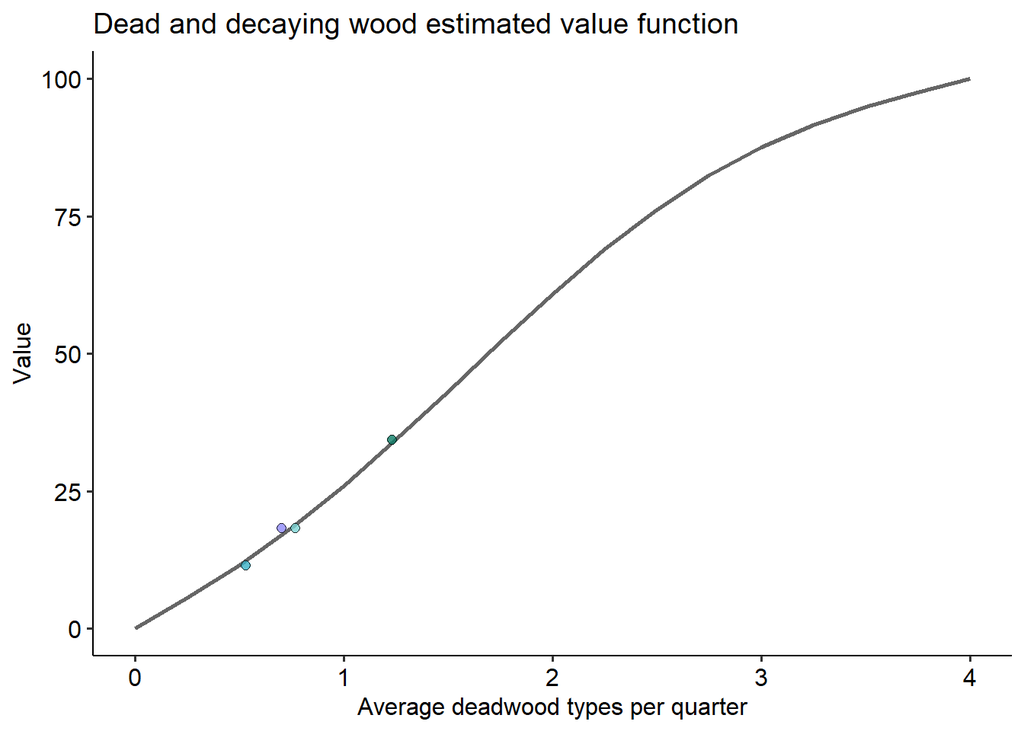

```r
ggplot() +
  geom_line(
    data = deadwood_predictions,
    aes(x = measure/4, y = value),
    color = "black", size = vf_size, alpha = vf_alpha
  ) +
  geom_point(
    data = dead_decaying_wood_summary,
    aes(
      x = average_N_type_quaters,
      y = value,
      fill = plot
    ),
    alpha = point_alpha,
    size = point_size,
    position = position_jitter(width = 0.05, height = 0),
    shape = 21, colour = "black"
  ) +
  scale_fill_manual(values= wt_palette[-c(1,2,4)]) +
  # Axes and titles
  labs(
    x = "Average deadwood types per quarter",
    y = "Value",
    title = paste(this.sheet, "estimated value function"),
    fill = "Plot type"
  ) +
  # Theme and tweaks
  theme_pubr() +
  theme(legend.position = "none")
```

```r
datatable(
  dead_decaying_wood_summary %>%
    mutate(
      value = round(value, 2),
      average_N_type_quaters = round(average_N_type_quaters, 2),
      N_type_quaters = as.character(N_type_quaters)
    ) %>%
    rename(
      Plot = plot,
      Value = value,
      'Average deadwood types per quarter' = average_N_type_quaters,
      'N type-quarters' = N_type_quaters
    ),
  rownames = FALSE,
  caption = "Dead and Decaying Wood Summary by Plot",
  options = list(
    pageLength = 10,
    dom = 't',
    ordering = FALSE,
    scrollX = TRUE  # ← Enables horizontal scrolling
  )
)
```

| Plot | Value | Average deadwood types per quarter | N type-quarters | In canopylength ≥ 0.5 m ; ø ≥ 20 cm | On ground length≥ 0.5 m ; ø ≥ 20 cm | Stumps< 1 m ø ≥ 20 cm | Standing height≥ 1m, ø ≥ 20 cm |
| --- | --- | --- | --- | --- | --- | --- | --- |
| 1 | 18.31 | 0.75 | 3 | 0 | 2 | 0 | 1 |
| 2 | 34.33 | 1.25 | 5 | 1 | 3 | 1 | 0 |
| 3 | 18.31 | 0.75 | 3 | 0 | 2 | 1 | 0 |
| 4 | 11.54 | 0.5 | 2 | 0 | 1 | 0 | 1 |

**Herbivore impact**

```r
this.sheet <- "Herbivore impact"
x.axis_title <- "Herbivore impact score"

herbivore_impact_summary <- create_herbivore_impact_summary()
```

92

The mean herbivore impact value across the zone is 92.11. Herbivore impact value is a function of the herbivore impact class assigned to each plot, which is based on the proportion of potential growth (over previous 12-months) removed by herbivores for palatable and unpalatable tree, shrub and indicator species.

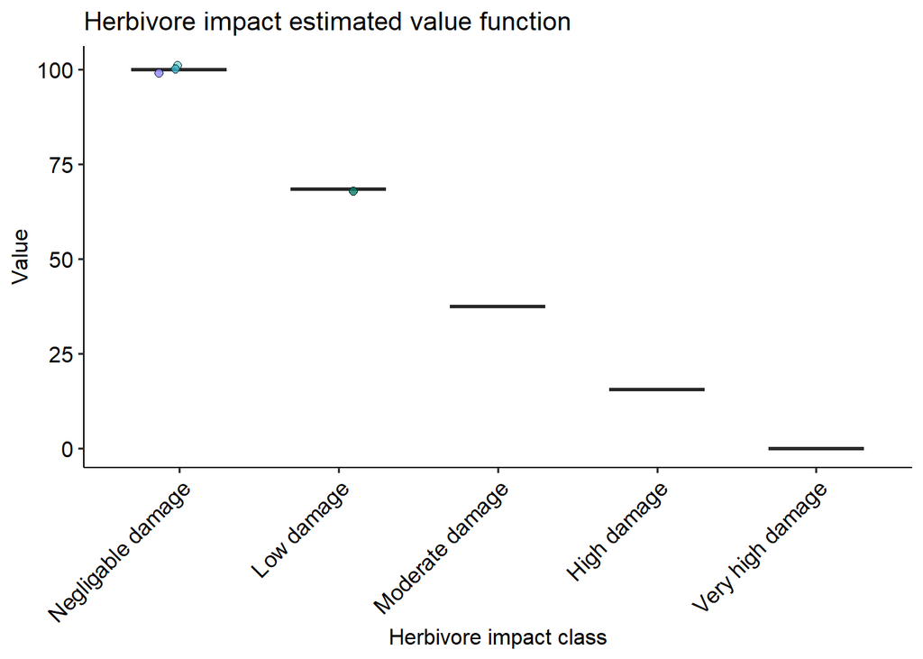

```r
ggplot() +
  geom_errorbar(
    data = Herbivore_impact_lookup,
    aes(
      x = herbivore_impact_class,
      ymin = value,
      ymax = value
    ),
    width = 0.6,          # controls horizontal length of line
    color = "black",
    size = vf_size,
    alpha = vf_alpha
  ) +
  geom_point(
    data = herbivore_impact_summary,
    aes(
      x = herbivore_impact_class,
      y = value,
      fill = plot
    ),
    alpha = point_alpha,
    size = point_size,
    position = position_jitter(width = 0.2, height = 1),
    shape = 21, colour = "black"
  ) +
  scale_fill_manual(values= wt_palette[-c(1,2,4)]) +
  # Axes and titles
  labs(
    x = "Herbivore impact class",
    y = "Value",
    title = paste(this.sheet, "estimated value function"),
    fill = "Plot type"
  ) +
  # Theme and tweaks
  theme_pubr() +
  theme(legend.position = "none",
        axis.text.x = element_text(angle = 45, hjust = 1)
)
```

```r
datatable(
  herbivore_impact_summary %>%
    mutate(
      value = round(value, 2),
      palatable_removed = palatable_removed,
      unpalatable_removed = unpalatable_removed) %>%
    rename(
      Plot = plot,
      Value = value,
      'Herbivore impact class' = herbivore_impact_class,
      'Palatable removed (%)' = palatable_removed,
      'Un-palatable removed (%)' = unpalatable_removed
    ),
  rownames = FALSE,
  caption = "Herbivore Impact Summary by Plot",
  options = list(
    pageLength = 10,
    dom = 't',
    ordering = FALSE
  )
)
```

| Plot | Value | Herbivore impact class | Palatable removed (%) | Un-palatable removed (%) |
| --- | --- | --- | --- | --- |
| 1 | 100 | Negligable damage | N/A - Vegetation absent due to non-herbivore reasons | N/A - Vegetation absent due to non-herbivore reasons |
| 2 | 68.43 | Low damage | 25-75% | &lt;25% |
| 3 | 100 | Negligable damage | N/A - Vegetation absent due to non-herbivore reasons | N/A - Vegetation absent due to non-herbivore reasons |
| 4 | 100 | Negligable damage | N/A - Vegetation absent due to non-herbivore reasons | N/A - Vegetation absent due to non-herbivore reasons |

**Tree health**

```r
this.sheet <- "Tree health"
x.axis_title <- "Tree health score"
tree_health_summary <- create_tree_health_summary()
```

67

The mean tree health value across the zone is 66.73.

Tree health value is a function of the worst of: a) canopy dieback percentage or b) tree sudden mortality percentage basal area, in each plot.

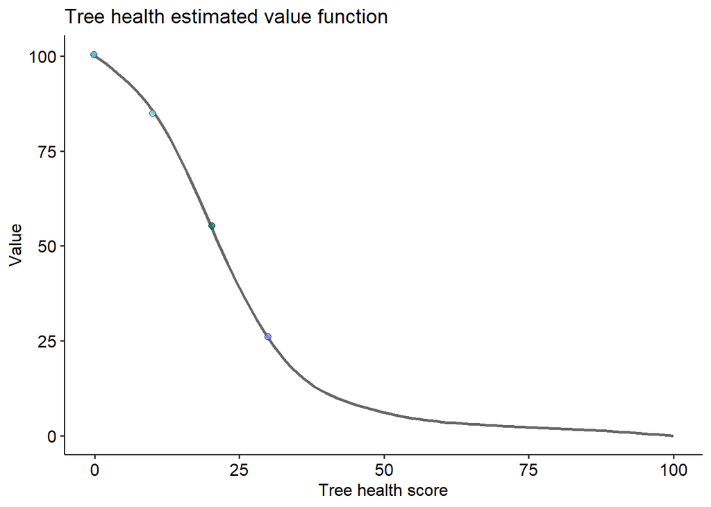

```r
ggplot() +
  geom_line(
    data = tree_health_predictions,
    aes(x = measure, y = value),
    color = "black", size = vf_size, alpha = vf_alpha
  ) +
  geom_point(
    data = tree_health_summary,
    aes(
      x = worst_indicator,
      y = value,
      fill = plot
    ),
    alpha = point_alpha,
    size = point_size,
    position = position_jitter(width = 0.2, height = 1),
    shape = 21, colour = "black"
  ) +
  scale_fill_manual(values= wt_palette[-c(1,2,4)]) +
  # Axes and titles
  labs(
    x = "Tree health score",
    y = "Value",
    title = paste(this.sheet, "estimated value function"),
    fill = "Plot type"
  ) +
  # Theme and tweaks
  theme_pubr() +
  theme(legend.position = "none")
```

```r
datatable(
  tree_health_summary %>%
    select(-worst_indicator) %>%  # remove worst indicator - supurfluous
    mutate(
      value = round(value, 2),
      dieback_per = round(dieback_per, 2),
      suddenmortality_per = round(suddenmortality_per, 2),
    ) %>%
    rename(
      Plot = plot,
      Value = value,
      'Canopy dieback (%)' = dieback_per,
      'Sudden mortality (%)' = suddenmortality_per,
    ),
  rownames = FALSE,
  caption = "Tree Health Summary by Plot",
  options = list(
    pageLength = 10,
    dom = 't',
    ordering = FALSE
  )
)
```

| Plot | Value | Canopy dieback (%) | Sudden mortality (%) |
| --- | --- | --- | --- |
| 1 | 25.76 | 30 |  |
| 2 | 55.47 | 20 |  |
| 3 | 85.67 | 10 |  |
| 4 | 100 | 0 |  |

**Anthropogenic damage**

```r
this.sheet <- "Anthropogenic damage"
x.axis_title <- "Anthropogenic damage score"
anthropogenic_damage_summary <- create_anthropogenic_damage_summary()
```

100

The mean anthropogenic damage value across the zone is 100.

Anthropogenic damage value is a function of the cover of anthropogenic damage in each plot.

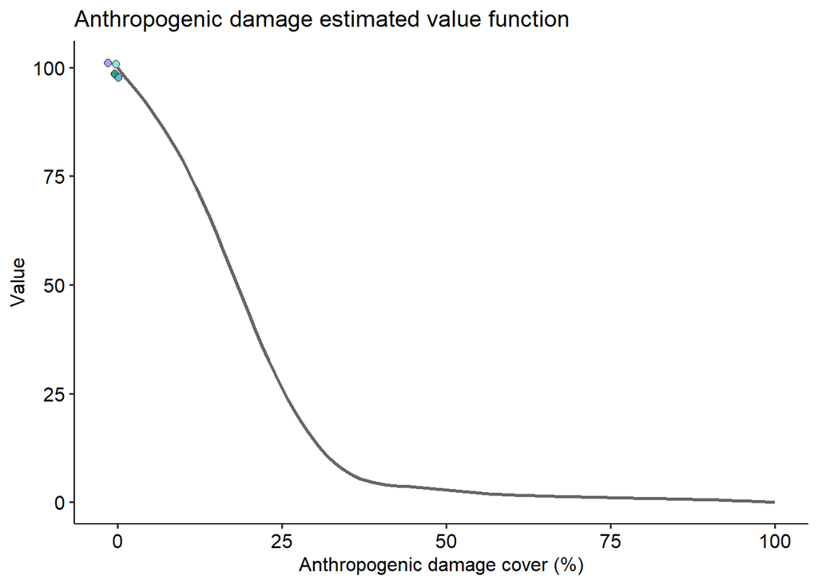

```r
anthro_plots_forplot <- anthropogenic_damage_summary %>%
      left_join(domin_transformer, by = c("damage_cover" = "domin"))%>%
  mutate(value_jit = value + runif(n(), -3, 3))  # manually jitter 'value'

# for testing
# anthro_plots_forplot$max = 20

antro_damage_domin_ranges <- anthro_plots_forplot[anthro_plots_forplot$max > anthro_plots_forplot$min, ]

ggplot() +
  # value function
  geom_line(
    data = anthropogenic_damage_predictions,
    aes(x = measure, y = value),
    color = "black", size = 1, alpha = vf_alpha
  ) +
  # segment for domin class cover range
  geom_segment( data = antro_damage_domin_ranges,
  aes(x = min, xend = max + 0.1, y = value_jit, yend = value_jit, colour = factor(plot)),
    size = 0.5, alpha = 0.7
  ) +
  # points for each plot at domin class mid point
  geom_point(
    data = anthro_plots_forplot ,
    aes(
      x = mid,
      y = value_jit,
      fill = plot
    ),
    alpha = point_alpha,
    size = point_size,
    shape = 21, colour = "black",
    position = position_jitter(width = 2, height = 0)
  ) +
  scale_fill_manual(values= wt_palette[-c(1,2,4)]) +
  # Axes and titles
  labs(
    x = "Anthropogenic damage cover (%)",
    y = "Value",
    title = paste(this.sheet, "estimated value function"),
    fill = "Plot type"
  ) +
  # Theme and tweaks
  theme_pubr() +
  theme(legend.position = "none")
```

```r
datatable(
  anthropogenic_damage_summary %>%
    mutate(
      value = round(value, 2),
      damage_cover = paste(damage_cover, "%", sep = "")
    ) %>%
    rename(
      Plot = plot,
      Value = value,
      'Damage cover (%)' = damage_cover
    ),
  rownames = FALSE,
  caption = "Anthropogenic Damage Summary by Plot",
  options = list(
    pageLength = 10,
    dom = 't',
    ordering = FALSE
  )
)
```

| Plot | Value | Damage cover (%) |
| --- | --- | --- |
| 1 | 100 | 0% Absent% |
| 2 | 100 | 0% Absent% |
| 3 | 100 | 0% Absent% |
| 4 | 100 | 0% Absent% |

**Ground flora**

```r
this.sheet <- "Ground flora"
x.axis_title <- "Ground flora cover (%)"
ground_flora_summary <- create_ground_flora_summary()
```

0

The mean ground flora value across the zone is 0.39.

Ground flora value is a function of the proportion of appropriate ground flora species present in each plot. The number appropriate ground flora species lists vary by habitat.

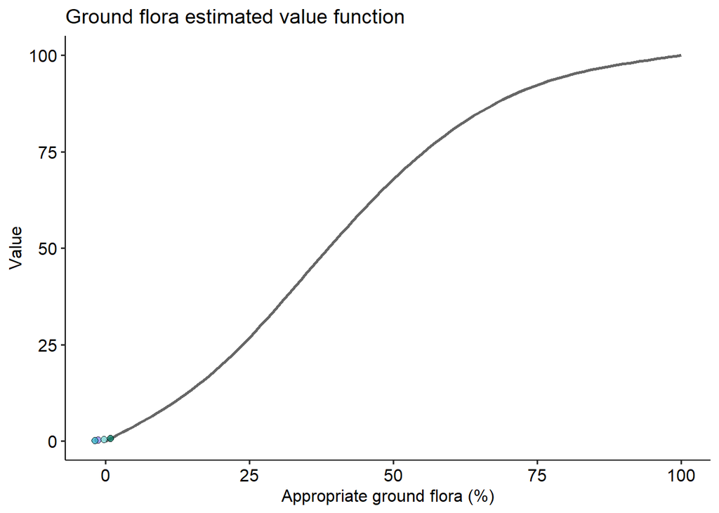

```r
ggplot() +
  geom_line(
    data = ground_flora_predictions,
    aes(x = measure, y = value),
    color = "black", size = vf_size, alpha = vf_alpha
  ) +
  geom_point(
    data = ground_flora_summary,
    aes(
      x = perc_of_appropriate_ground_flora,
      y = value,
      fill = plot
    ),
    alpha = point_alpha,
    size = point_size,
    position = position_jitter(width = 2, height = 1),
    shape = 21, colour = "black"
  ) +
  scale_fill_manual(values= wt_palette[-c(1,2,4)]) +
  # Axes and titles
  labs(
    x = "Appropriate ground flora (%)",
    y = "Value",
    title = paste(this.sheet, "estimated value function"),
    fill = "Plot type"
  ) +
  # Theme and tweaks
  theme_pubr() +
  theme(legend.position = "none")
```

```r
datatable(
  ground_flora_summary %>%
    mutate(
      value = round(value, 1),
      perc_of_appropriate_ground_flora = paste(round(perc_of_appropriate_ground_flora, 1), "%", sep = ""),
      N_plant_spp = as.character(N_plant_spp),
      N_appropriate_ground_flora = as.character(N_appropriate_ground_flora)
    ) %>%
    rename(
      Plot = plot,
      Value = value,
      'Appropriate ground flora (%)' = perc_of_appropriate_ground_flora,
      'N appropriate species' = N_appropriate_ground_flora,
      'N species' = N_plant_spp
    ),
  rownames = FALSE,
  caption = "Ground Flora Summary by Plot",
  options = list(
    pageLength = 10,
    dom = 't',
    ordering = FALSE,
    scrollX = TRUE  # ← Enables horizontal scrolling
  )
)
```

| Plot | Value | Appropriate ground flora (%) | N appropriate species | N species | Moss sp. | Bramble | Grass sp. | Herb Robert | Nettle | Wood sorrel | Bracken |
| --- | --- | --- | --- | --- | --- | --- | --- | --- | --- | --- | --- |
| 1 | 0 | 0% | 0 | 1 | &lt; 4% ( Rare - 1 Few individuals) | 0% Absent | 0% Absent | 0% Absent | 0% Absent | 0% Absent | 0% Absent |
| 2 | 1.5 | 2% | 1 | 6 | 4 - 10% (Rare - 4) | &lt; 4% ( Rare - 2 Several individuals) | 4 - 10% (Rare - 4) | &lt; 4% ( Rare - 1 Few individuals) | &lt; 4% ( Rare - 3 Many individuals) | 26 – 33% (Frequent - 6) | 0% Absent |
| 3 | 0 | 0% | 0 | 0 | 0% Absent | 0% Absent | 0% Absent | 0% Absent | 0% Absent | 0% Absent | 0% Absent |
| 4 | 0 | 0% | 0 | 1 | 0% Absent | 0% Absent | 0% Absent | 0% Absent | 0% Absent | 0% Absent | &lt; 4% ( Rare - 3 Many individuals) |

.

.

.

.

.

.

.

.

.

.

.

.

.

.

.

.

.

.

.

.

.

.

.

.

.

.

.

.

.

.

.

.

Just some intentionally blank space. Why? Reasons.